# 03 Fundamental Concepts

```r
# Define a function
linear <- function(x)
  ifelse( x <= 0, 0,
  ifelse( x > 0 & x <= 1, 2 * x, 0 ))

# Create a data frame for plotting
df <- data.frame(x =seq(from = 0, to = 1, by = 0.01)) %>% mutate(y = linear(x))

# Plot
ggplot(data = df, aes(x, y)) +
  geom_area(fill = "orange", alpha = 0.5) +
  ylim(c(0, 2)) + # Set the limits of the y axis
  geom_hline(yintercept = 0) + # Add y axis
  geom_vline(xintercept = 0) + # Add x axis
  ylab("f(x)") # Label the y axis
```

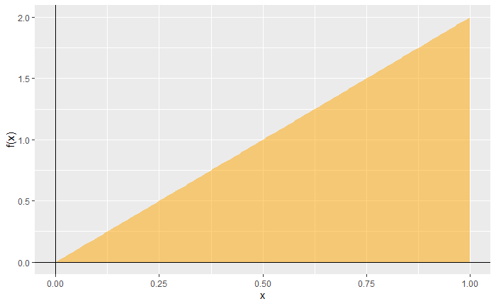

Clearly, $f(x) \ge 0$ for all values of $x$ in the interval $0 \le x \le 1$. We can verify that the area under the curve is 1. In this case the area is that of a triangle, i.e., $\frac{b \times h}{2}$. Since the base of the triange is $b=1$ and the height is $h=2$, we see that the area under the curve is 1.

Since this is a valid probability distribution function, we can use it to calculate the probability of $x \le X$ as above. The area under the curve when $x \le X$ is given by:
$$F(x) = \left\{
\begin{array}{lc}
0 & \quad x \le 0 \\
\frac{x \times 2x}{2} = x^2 & \quad 0 < x < 1 \\
1 & \quad x \ge 1 \\
\end{array}
\right.$$

```r
# Define a function
clinear <- function(x)
  ifelse( x <= 0, 0,
  ifelse( x > 0 & x <= 1, x^2, 1 ))

# Create a data frame for plotting
df <- data.frame(x =seq(from = -0.2, to = 1.2, by = 0.001)) %>% mutate(y = clinear(x))

# Plot
ggplot(data = df, aes(x, y)) +
  geom_step(color = "orange") +  # Plot cumulative distribution function
  ylim(c(0, 1)) + # Set the limits of the y axis
  geom_hline(yintercept = 0) + # Add y axis
  geom_vline(xintercept = 0) + # Add x axis
  ylab("F(x)") # Label the y axis
```

[figure not shown]

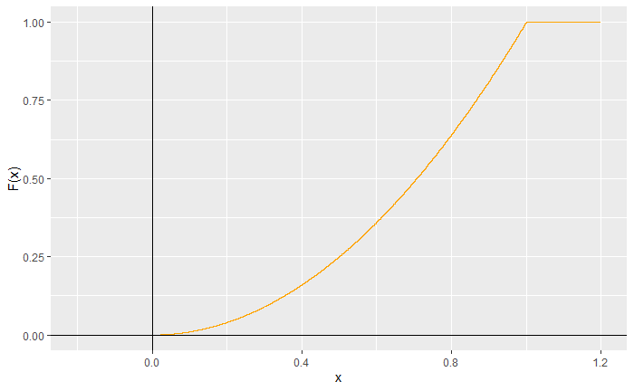

```r
# Define a function
cubic <- function(x)
  ifelse( x <= 0, 0,
  ifelse( x > 0 & x <= 1, 4 * x^3, 0 ))

# Create a data frame for plotting
df <- data.frame(x =seq(from = 0, to = 1, by = 0.01)) %>% mutate(y = cubic(x))

# Plot
ggplot(data = df, aes(x, y)) +
  geom_area(fill = "orange", alpha = 0.5) +
  ylim(c(0, 4)) + # Set the limits of the y axis
  geom_hline(yintercept = 0) + # Add y axis
  geom_vline(xintercept = 0) + # Add x axis
  ylab("f(x)") # Label the y axis
```

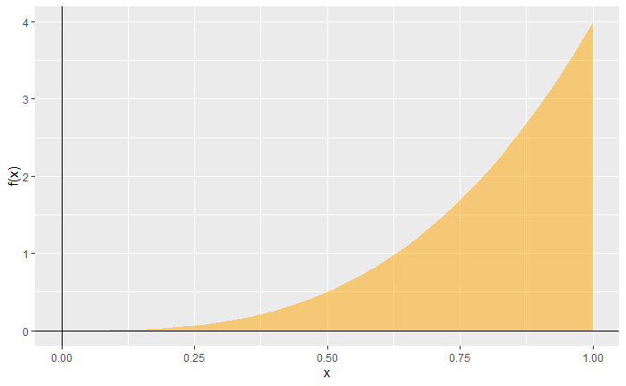

## A simple random utility discrete choice model

We are now ready to deploy a probability distribution function to the probability of choosing an alternative. Returning to our binary choice example, lets assume that the difference in the random utility terms follows the uniform distribution with parameters $-L$ and $L$, that is:
$$\epsilon_{\text{New-Phone}} - \epsilon_{\text{Do-Nothing}} \sim U(-L, L)$$

The probability of choosing the "do-nothing alternative" is:
$$P_{\text{Do-Nothing}} = P(V_{\text{Do-Nothing}} - V_{\text{New-Phone}} > \epsilon_{\text{New-Phone}} - \epsilon_{\text{Do-Nothing}})$$

Since we know the probabilities of a random variable being less than a certain value in the uniform distribution, we have that:
$$P_{\text{Do-Nothing}} = \left\{
\begin{array}{lc}
0 & \quad V_{\text{Do-Nothing}} - V_{\text{New-Phone}} \le -L \\
\frac{V_{\text{Do-Nothing}} - V_{\text{New-Phone}} + L}{2L} & \quad -L< V_{\text{Do-Nothing}} - V_{\text{New-Phone}} < L \\
1 & \quad V_{\text{Do-Nothing}} - V_{\text{New-Phone}} \ge L \\
\end{array}
\right.$$

We can unpack this expression as follows.

When the systematic utility of a new phone is greater than the systematic utility of doing nothing, the difference between these two terms is negative. The more negative this value is, the lower the probability of doing nothing. When the difference is more negative than $-L$, the probability of doing nothing becomes zero.

When the systematic utility of a new phone is identical to the systematic utility of doing nothing, the difference between these two terms is zero, in which case the probability of doing nothing is $0.5$. In other words, there is a 50% chance that the decision maker will do nothing.

Finally, when the systematic utility of a new phone is less than the systematic utility of doing nothing, the difference between these two terms is positive. The more the more positive this value is, the higher the probability of doing nothing. When the difference is greater than $L$, the probability of doing nothing becomes one.

Now, since the choice set is an exhaustive collection of courses of action, it follows that the probability of the two courses of action must add up to one (the decision-maker does nothing OR buys a new phone):
$$P_{\text{Do-Nothing}} + P_{\text{New-Phone}} = 1$$

This implies that once we know the probability of doing nothing, the probability of buying a new phone is simply the complement:
$$P_{\text{New-Phone}} = 1 - P_{\text{Do-Nothing}}$$

These probabilities are a discrete choice model. In fact, this is called the linear probability model [see @Benakiva1985discrete, pp. 66-68]. Other models can be obtained by selecting different probability distribution functions, as we will see in later chapters. The procedure followed here will be the same, even if the probability distribution function selected for the model is different: given a valid probability distribution function, and given the systematic utilities of the alternatives, it is possible to evaluate the probabilistic statement associated with the choice of an alternative.

On a final note, before discussing other choice mechanisms. The simple example used here was a binomial choice choice situation, i.e., a situation with only two alternatives. This was done for convenience of exposition, and we will see how the same ideas generalize for situations with more than two alternatives, that is, for multinomial choice situations.

## Other choice mechanisms

For example, a user who is shopping for smartphones may have low tolerance for download speeds below a certain threshold, or may have a budget limit that prevents her from considering certain models. Some alternatives from the choice set may be eliminated or ranked based on some dominant attribute. This kind of choice mechanism is called *lexicographic* choice, or elimination by attributes.

Another plausible choice mechanism is a form of satisficing behavior. Again, a user shopping for a smartphone might find a model that does not maximize her utility, but that is otherwise satisfactory. For example, the decision-maker may consider that the additional time spent finding an even better model is not worth her while, so she stops her search at a suboptimal point.

Another choice mechanism seen recently in the literature is regret-minimization [@Chorus2010new].

In addition to these various mechanisms, it is possible that a decision-maker deploys combinations of them: for example, lexicographic choice to reduce the number of alternatives in a choice set, followed by utility maximization or regret minimization. There has been much progress on these models, but for the time being utility maximization remains the most widely used approach for the analysis of discrete choices.

## Exercise

Answer the following questions.

### Questions

1. Define utility.
2. Describe in your own words the behavior described by utility maximization.
3. What conditions are necessary for a function to be a valid probability distribution function?

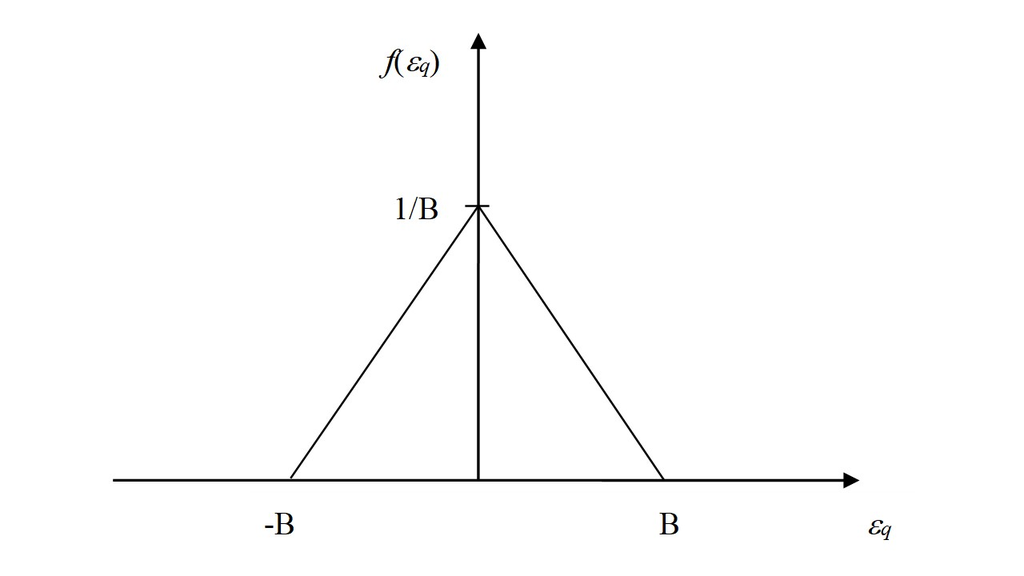

4. Show that the triangle function in the figure is a valid probability distribution function.

Next, consider the following utility functions for two alternatives, namely $i$ and $j$:
$$\begin{array}{c}
U_i = V_i + \epsilon_i\\
U_j = V_j + \epsilon_j\\
\end{array}$$

Assume that the difference between the error terms below follows the triangle distribution:
$$\epsilon_q = \epsilon_i - \epsilon_j$$

5. Parting from the assumption above, derive a binary choice model for the probability of selecting alternative $j$.